# Informe Técnico

Juan José Galeano Arenas

Simón Pedro Galeano Muñoz

Sebastian Gaviria Sanchez

Verónica Ríos Vargas

En este informe se muestra el proceso de creación de variables para la construcción del modelo así como hallazgos encontrados para el proceso de modelación.

# Construcción de la base de datos

La base de datos originalmente contaba con dos variables, fecha y unidades (la cual es la variable respuesta). Esta base estaba limpia pues no se encontraron incongruencias, valores faltantes, entre otros.

## Creación de variables

### Variables categóricas

Inicialmente se usó la fecha para crear las variables día, mes, año y semana. Para dicho propósito se usaron las funciones `wday()`, `month`, `year()`, y `week()` de la librería `lubridate`. Dichas funciones fueron aplicadas a la variable fecha, la cual fue transformada previamente en un objeto de la clase date con la función `as.Date()` del paquete `base` de R. Por último se consideró la variable festivos la cual se construyó gracias a un repositorio de GitHub (Nequi Colombia 2017) donde se encontró un módulo node.js el cual a través de JavaScript se pudo exportar a un objeto JSON, luego se usó la función `fromJSON()` de la librería `rjson` para poder trabajar con JavaScript Objects Notation (JSON) en R y así extraer los datos de los días festivos en Colombia.

### Variables numéricas

En este caso se consideraron variables numéricas las cuales tienen que ver con el cambio económico del país a lo largo de los años puesto que el aumento o decremento de estas podría afectar el poder adquisitivo de los ciudadanos. Dichas variables fueron: PIB anual, PIB persona (Banco de la república, n.d.b), tasa de cambio representativo del mercado del dolar (TRM) (Banco de la república, n.d.d), salario mínimo (Banco de la república, n.d.c), índice de precios al consumidor (IPC) e inflación mensual (Banco de la república, n.d.a). Todas estas variables fueron tomadas de internet en páginas gubernamentales y luego fueron agregadas a la base de datos gracias a diversas funciones de la librería `dplyr` como `inner_join()`, `mutate()`, `filter()`, `select()`, entre otras.

| Fecha | Unidades | Día | Mes | Año | Semana | Festivo | PIB anual | PIB persona | TRM | Salario mínimo | IPC | Inflación mensual |
| --- | --- | --- | --- | --- | --- | --- | --- | --- | --- | --- | --- | --- |
| 2012-01-01 | 0 | dom | ene | 2012 | 1 | Si | 3.912636 | 2.943729 | 1942.70 | 566700 | 76.75 | 0.73 |
| 2012-01-02 | 188 | lun | ene | 2012 | 1 | No | 3.912636 | 2.943729 | 1942.70 | 566700 | 76.75 | 0.73 |
| 2012-01-03 | 482 | mar | ene | 2012 | 1 | No | 3.912636 | 2.943729 | 1942.70 | 566700 | 76.75 | 0.73 |
| 2012-01-04 | 927 | mié | ene | 2012 | 1 | No | 3.912636 | 2.943729 | 1915.02 | 566700 | 76.75 | 0.73 |
| 2012-01-05 | 1159 | jue | ene | 2012 | 1 | No | 3.912636 | 2.943729 | 1898.24 | 566700 | 76.75 | 0.73 |
| 2012-01-06 | 996 | vie | ene | 2012 | 1 | No | 3.912636 | 2.943729 | 1884.44 | 566700 | 76.75 | 0.73 |

# Análisis descriptivo

En esta sección se presentan diversos gráficos para detectar posibles relaciones entre las covariables y la respuesta.

### Distribución del número global de vehículos registrados en los distintos días de la semana

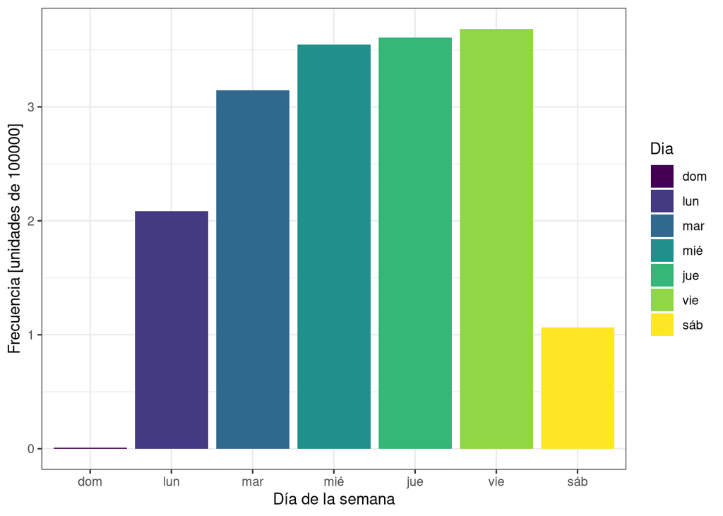

Unidades registradas en cada día de la semana (global)

En este gráfico se logra apreciar una clara discrepancia entre el número de vehículos registrados en los diferentes días de la semana siendo sábado aquel día en el que, objetivamente, menos registros se presentan. La escasez de registros del domingo es debida a que “no se registran vehículos” en este día, sin embargo no debería tener observaciones; la frecuencia no nula del mismo se podría deber a retrasos en los sistemas informáticos o demás anomalías en el horario laboral.

### Distribución del número de vehiculos registrados en los distintos días de la semana discriminando por año

El análisis previo se desarrolló de manera global, sin embargo, surge la duda de si dicho comportamiento cambia en los distintos años o se mantiene igual.

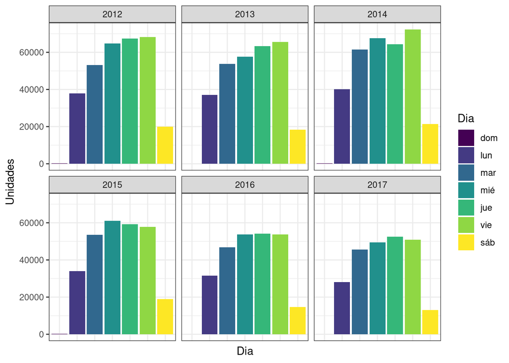

Unidades registradas en cada día de la semana (anual)

Observe que el número de registros por día se distribuye de forma similar a lo largo de los años, también se aprecia que a medida que avanzan los años el número de registros es menor lo cual sugiere que existen fenómenos que han afectado el poder adquisitivo de las personas.

### Correlación lineal entre variables numéricas

La correlación lineal interesa por dos principales razones:

- Observar si un modelo lineal es útil para predecir el número de vehículos registrados un día particular.
- Evitar potenciales problemas de multicolinealidad producido por covariables que estén muy correlacionadas.

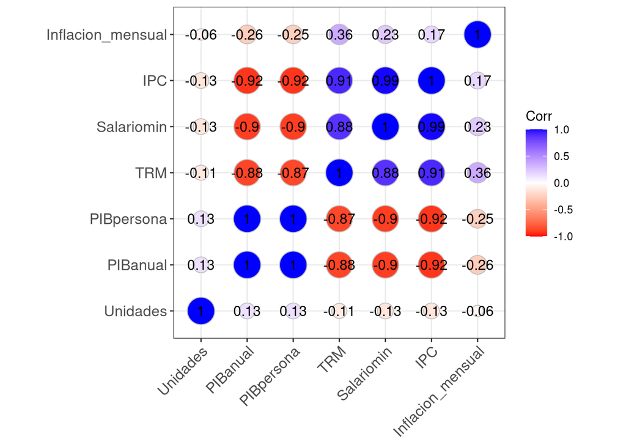

Correlación lineal entre variables numéricas

Note que la correlación lineal entre la variable respuesta y cada una de las covariables es muy baja por lo que un modelo lineal usando los regresores crudos puede no ser adecuado. Por otro lado, a excepción de la inflación mensual, los predictores están muy correlacionados linealmente y por lo tanto pueden provocar potentes problemas de multicolinealidad, luego en caso de usar variables numéricas en modelos sensibles a la multicolinealidad se debería tomar únicamente una de estas.

### Diagramas de dispersión para Unidades vs regresores

Puesto que las correlaciones lineales son muy bajas, se grafican diagramas de dispersión con el propósito de hallar posibles relaciones de otro tipo entre el número de registros de vehículos diarios y las variables predictoras numéricas.

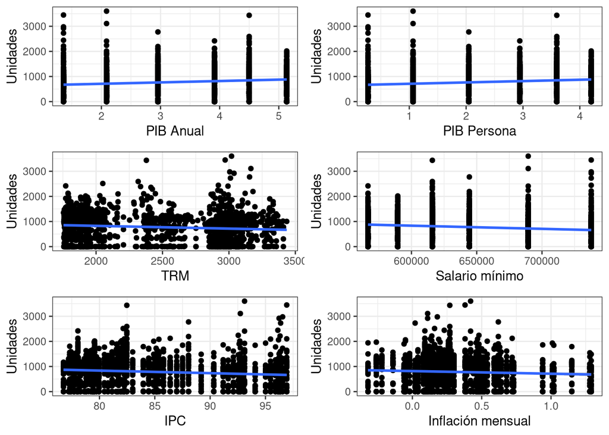

Diagramas de dispersión

En ningún caso se logra detectar algún tipo de relación funcional entre las covariables y la respuesta lo cual sugiere que estas variables pueden no ser útiles para el proceso de modelación.

# Modelación

Para el proceso de modelación se consideran los modelos aditivos generalizados para localización, escala y forma (Stasinopoulos et al. 2017) (GAMLSS por sus siglas en inglés). Estos modelos constituyen una gran gama de posibilidades para ajustar modelos de regresión donde no se cumple el supuesto de normalidad y/o homocedasticidad. Los modelos GAMLSS son muy flexibles puesto que permiten modelar hasta 4 parámetros de una distribución de probabilidad con diferentes funciones de suavizamiento, en general, un modelo gamlss es de la forma.

$$\mathbf{Y} \stackrel{\text{iid}}{\sim} \mathcal{D}(\mathbf{\mu, \sigma, \nu,\tau}) \\
\mathbf{\eta_1} = g_1(\mathbf{\mu}) \\
\mathbf{\eta_2} = g_2(\mathbf{\sigma}) \\
\mathbf{\eta_3} = g_3(\mathbf{\nu}) \\
\mathbf{\eta_4} = g_4(\mathbf{\tau})$$
donde $\mathbf{\mu}$ es el parámetro de localización, $\mathbf{\sigma}$ escala y $\mathbf{\nu}, \mathbf{\tau}$ son parámetros de forma (Stasinopoulos et al. 2017).

Teniendo en cuenta el análisis descriptivo, se decidió buscar una distribución de probabilidad que se ajuste de mejor forma a los datos puesto que, la densidad empírica de la respuesta no se parece a una distribución normal, Para este propósito se usa la función `fitDist()` de la librería `gamlss`. Dicha función busca en un amplio catálogo de distribuciones y encuentra la más adecuada usando el criterio de información de Akaike generalizado (GAIC), esto es:

$$\text{GAIC} = -2\hat{l} + k(df)$$
Con $\hat{l}$ el valor de log-verosimilitud del modelo en cuestión, $df$ los grados de libertad y $k$ un valor escogido para penalizar el exceso de parámetros (Hernández and Usuga 2021). Por defecto `fitDist()` toma $k=2$ y el GAIC se convierte en el AIC convencional. `fitDist()` tiene diversos argumentos, entre ellos se encuentra “type” en el cual se especifica el dominio de las distribuciones a usar, para el problema en cuestión se usa la función para que busque distribuciones de tipo conteo debido a la naturaleza del problema presentado y se obtienen un total de 30 distribuciones tentativas.

Las distribuciones con menor AIC fueron binomiales negativas con ceros ajustados e inflados respectivamente (ZANBI y ZINBI). En las demás distribuciones destacan la geométrica, poisson, poisson con ceros inflados, poisson generalizada entre otras, sin embargo el ajuste no fue tan satisfactorio como los dos primeros debido a que se encontraron diferencias sustanciales entre los AIC.

## Selección del mejor modelo usando cross - validation

Se utilizó la metodología de cross - validation para evaluar diversos modelos y encontrar aquel que mejor explique el número de vehículos registrados en un día particular sin caer en sobreajuste. Se tomaron los datos del año 2012 - 2016 como datos de entrenamiento mientras que los datos de 2017 se dejaron como conjunto de validación. Inicialmente se probaron modelos con diversas combinaciones de variables categóricas y numéricas pero, desafortunadamente, las variables numéricas empeoraron el desempeño del modelo en todos los casos sin importar la distribución que se estuviera usando, por lo que se decidió no incluirlas en el mismo.

Para finalizar, cabe mencionar que también se ajustó un bosque aleatorio (random forest) y una regresión knn, sin embargo dicho modelos tuvieron un rendimiento demasiado pobre: el random forest sobreajustó considerablemente mientras que la regresión knn obtuvo predicciones muy pobres.

Luego de ajustar los modelos se calcularon los coeficientes de determinación $R^2$ tanto en el conjunto de entrenamiento como en el de prueba se obtuvieron los siguientes resultados:

|  | $R_{\text{train}}^2$ | $R_{\text{test}}^2$ | \|$R_{\text{train}}^2 - R_{\text{test}}^2$\| |
| --- | --- | --- | --- |
| ZANBI | 0.8377 | 0.7417 | 0.0960 |
| ZINBI | 0.8369 | 0.7425 | 0.0944 |
| ZIP | 0.8464 | 0.7189 | 0.1275 |
| GEOM | 0.7751 | 0.7164 | 0.0587 |
| KNN | 0.6844 | 0.2696 | 0.4148 |
| RF | 0.9567 | 0.7344 | 0.2223 |

Se destaca los pobres desempeños del random forest (overfitting) y regresión knn (underfitting) tal como se mencionó previamente. Por otro lado, el modelo GAMLSS usando respuesta poisson inflada en cero aunque no cumple el criterio de prueba, su desempeño es destacable.

Para finalizar, quedan los modelos con respuesta ZANBI, ZINBI y GEOM, note que los dos primeros tienen un desempeño muy similar y se podría escoger cualquiera de los dos. Para esta situación se toma el modelo que considera respuesta ZINBI debido a que la diferencia entre el $R^2_{\text{train}}$ y $R^2_{\text{test}}$ es ligeramente menor respecto al modelo con respuesta ZANBI. Finalmente se tiene el modelo con respuesta geométrica, si bien tiene un porcentaje de variabilidad explicada menor respecto a los modelos con respuesta ZANBI y ZINBI es más consistente debido a que tiene menor variación entre el $R^2_{\text{train}}$ y $R^2_{\text{test}}$.

Dados los resultados de desempeño expuestos anteriormente, y la naturaleza del problema en cuestión, se toma finalmente la decisión de usar el modelo ajustado teniendo en cuenta una respuesta que se distribuye binomial negativa inflada en cero (ZINBI). Esta última se decide apropiada ya que en general, su propósito es modelar variables aleatorias con un recuento importante de ceros, además de ser idónea para conteos, el cual es el caso. Adicionalmente, otra caracerística de valor para el problema, es que esta distribución también puede ser adecuada modelar recuentos muy dispersos, propiedad de gran provecho para este propósito.

# Bibliografía

Banco de la república. n.d.a. “Índice de Precio Al Consumidor (IPC),” https://www.banrep.gov.co/es/estadisticas/indice-precios-consumidor-ipc.

———. n.d.b. “Producto Interno Bruto (PIB).” https://www.banrep.gov.co/es/estadisticas/producto-interno-bruto-pib.

———. n.d.c. “Salarios.” https://www.banrep.gov.co/es/estadisticas/salarios.

———. n.d.d. “Tasa Representativa Del Mercado.” https://www.banrep.gov.co/es/estadisticas/trm.

Hernández, Freddy, and Olga Usuga. 2021. “Manual de r.” 2021. https://fhernanb.github.io/Manual-de-R/.

Nequi Colombia. 2017. “Colombia Holidays.” 2017. https://github.com/nequibc/colombia-holidays.

Stasinopoulos, Mikis D., Robert A. Rigby, Gillian Z. Heller, Vlasios Voudouris, and Fernanda De Bastiani. 2017. *Flexible Regression and Smoothing Using GAMLSS in r*. 1st ed. Chapman; Hall/CRC.